# Predictive Analytics in Supply Chain Management: A Classification Model for Assessing Delivery Timeliness

2023-12-12

# Introduction

In today’s competitive market, the ability to predict delivery times accurately is crucial for the success of supply chain operations. This report introduces a robust classification model, leveraging predictive analytics to determine whether products will be delivered on time, thereby enhancing efficiency and customer satisfaction in supply chain management

### Background

- Predicting delivery times accurately is a tough task for businesses. When deliveries don’t arrive as planned, customers can become dissatisfied, and businesses often have to compensate them with refunds or discounts. This not only costs money but can also disrupt their inventory management.
- The traditional methods of predicting delivery times aren’t always reliable, especially when unexpected issues occur. By using various machine learning algorithms, we can build a model that predicts whether a product will be delivered on time or not.
- This approach helps businesses improve their predictions about delivery times, which in turn keeps customers happier, reduces costs, and makes the whole supply chain run more efficiently.

### Purpose of the Report

This report presents a comprehensive summary of our project, which involved developing a classification model using predictive analytics to accurately forecast whether a product will be delivered on time or experience delays.

# Data Pre-processing

```r
data= read.csv('DataCoSupplyChainDataset.csv')
head(data,1)
```

```
##    Type Days.for.shipping..real. Days.for.shipment..scheduled.
## 1 DEBIT                        3                             4
##   Benefit.per.order Sales.per.customer  Delivery.Status Late_delivery_risk
## 1             91.25             314.64 Advance shipping                  0
##   Category.Id  Category.Name Customer.City Customer.Country Customer.Email
## 1          73 Sporting Goods        Caguas      Puerto Rico      XXXXXXXXX
##   Customer.Fname Customer.Id Customer.Lname Customer.Password Customer.Segment
## 1          Cally       20755       Holloway         XXXXXXXXX         Consumer
##   Customer.State          Customer.Street Customer.Zipcode Department.Id
## 1             PR 5365 Noble Nectar Island              725             2
##   Department.Name Latitude Longitude       Market Order.City Order.Country
## 1         Fitness 18.25145 -66.03706 Pacific Asia     Bekasi     Indonesia
##   Order.Customer.Id order.date..DateOrders. Order.Id Order.Item.Cardprod.Id
## 1             20755         1/31/2018 22:56    77202                   1360
##   Order.Item.Discount Order.Item.Discount.Rate Order.Item.Id
## 1               13.11                     0.04        180517
##   Order.Item.Product.Price Order.Item.Profit.Ratio Order.Item.Quantity  Sales
## 1                   327.75                    0.29                   1 327.75
##   Order.Item.Total Order.Profit.Per.Order   Order.Region     Order.State
## 1           314.64                  91.25 Southeast Asia Java Occidental
##   Order.Status Order.Zipcode Product.Card.Id Product.Category.Id
## 1     COMPLETE            NA            1360                  73
##   Product.Description                                Product.Image Product.Name
## 1                  NA http://images.acmesports.sports/Smart+watch  Smart watch
##   Product.Price Product.Status shipping.date..DateOrders.  Shipping.Mode
## 1        327.75              0             2/3/2018 22:56 Standard Class
```

```r
str(data)
```

```
## 'data.frame':    180519 obs. of  53 variables:
##  $ Type                         : chr  "DEBIT" "TRANSFER" "CASH" "DEBIT" ...
##  $ Days.for.shipping..real.     : int  3 5 4 3 2 6 2 2 3 2 ...
##  $ Days.for.shipment..scheduled.: int  4 4 4 4 4 4 1 1 2 1 ...
##  $ Benefit.per.order            : num  91.2 -249.1 -247.8 22.9 134.2 ...
##  $ Sales.per.customer           : num  315 311 310 305 298 ...
##  $ Delivery.Status              : chr  "Advance shipping" "Late delivery" "Shipping on time" "Advance shipping" ...
##  $ Late_delivery_risk           : int  0 1 0 0 0 0 1 1 1 1 ...
##  $ Category.Id                  : int  73 73 73 73 73 73 73 73 73 73 ...
##  $ Category.Name                : chr  "Sporting Goods" "Sporting Goods" "Sporting Goods" "Sporting Goods" ...
##  $ Customer.City                : chr  "Caguas" "Caguas" "San Jose" "Los Angeles" ...
##  $ Customer.Country             : chr  "Puerto Rico" "Puerto Rico" "EE. UU." "EE. UU." ...
##  $ Customer.Email               : chr  "XXXXXXXXX" "XXXXXXXXX" "XXXXXXXXX" "XXXXXXXXX" ...
##  $ Customer.Fname               : chr  "Cally" "Irene" "Gillian" "Tana" ...
##  $ Customer.Id                  : int  20755 19492 19491 19490 19489 19488 19487 19486 19485 19484 ...
```

[output cut: 39 more lines]

```r
data$`Customer.Full.Name` <- paste(data$`Customer.Fname`, data$`Customer.Lname`)
```

```r
colSums(is.na(data))
```

```
##                          Type      Days.for.shipping..real.
##                             0                             0
## Days.for.shipment..scheduled.             Benefit.per.order
##                             0                             0
##            Sales.per.customer               Delivery.Status
##                             0                             0
##            Late_delivery_risk                   Category.Id
##                             0                             0
##                 Category.Name                 Customer.City
##                             0                             0
##              Customer.Country                Customer.Email
##                             0                             0
##                Customer.Fname                   Customer.Id
##                             0                             0
##                Customer.Lname             Customer.Password
##                             0                             0
##              Customer.Segment                Customer.State
##                             0                             0
##               Customer.Street              Customer.Zipcode
##                             0                             3
##                 Department.Id               Department.Name
##                             0                             0
##                      Latitude                     Longitude
##                             0                             0
##                        Market                    Order.City
##                             0                             0
##                 Order.Country             Order.Customer.Id
##                             0                             0
##       order.date..DateOrders.                      Order.Id
##                             0                             0
##        Order.Item.Cardprod.Id           Order.Item.Discount
##                             0                             0
##      Order.Item.Discount.Rate                 Order.Item.Id
##                             0                             0
##      Order.Item.Product.Price       Order.Item.Profit.Ratio
##                             0                             0
##           Order.Item.Quantity                         Sales
##                             0                             0
##              Order.Item.Total        Order.Profit.Per.Order
##                             0                             0
##                  Order.Region                   Order.State
##                             0                             0
##                  Order.Status                 Order.Zipcode
##                             0                        155679
##               Product.Card.Id           Product.Category.Id
##                             0                             0
##           Product.Description                 Product.Image
##                        180519                             0
##                  Product.Name                 Product.Price
##                             0                             0
##                Product.Status    shipping.date..DateOrders.
##                             0                             0
##                 Shipping.Mode            Customer.Full.Name
##                             0                             0
```

```r
data$Customer.Email <- NULL
data$Customer.Password <- NULL
data$Order.Zipcode <-NULL
data$Product.Description <- NULL
data$Product.Image<-NULL
data$order.date..DateOrders. <- NULL
data$shipping.date..DateOrders.<- NULL
data$Customer.Fname <- NULL
data$Customer.Lname <- NULL
data$Product.Status <-NULL
data$Customer.Street <- NULL
data$Latitude<- NULL
data$Longitude <- NULL
data <- na.omit(data)
```

```r
value_counts <- table(data$Late_delivery_risk)
```

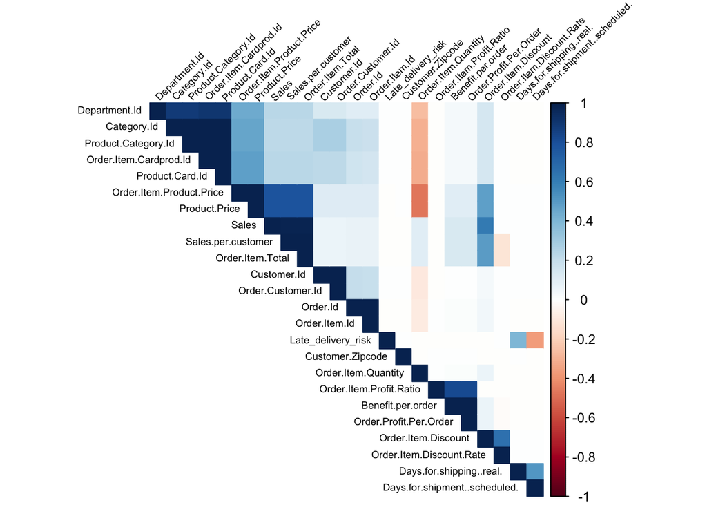

```r
library(corrplot)
numeric_data <- data[, sapply(data, is.numeric)]
cor_matrix <- cor(numeric_data)

corrplot(cor_matrix, method = "color", type = "upper", order = "hclust", tl.col = "black", tl.srt = 45,number.cex = 0.6,tl.cex = 0.6,)
```

Based on the insights from the correlation matrix, it’s evident that columns such as Order.Item.Product.Price, Sales.per.customer, Order.Item.Total, Order.customer.Id, and Order.Profit.Per.Order are repetitive. Therefore, these columns have been removed from the analysis.

```r
data$Order.Item.Product.Price <- NULL
data$Sales.per.customer <- NULL
data$Order.Item.Total <- NULL
data$Order.Customer.Id <- NULL
data$Order.Item.Id <- NULL
data$Order.Profit.Per.Order <- NULL
```

# EDA

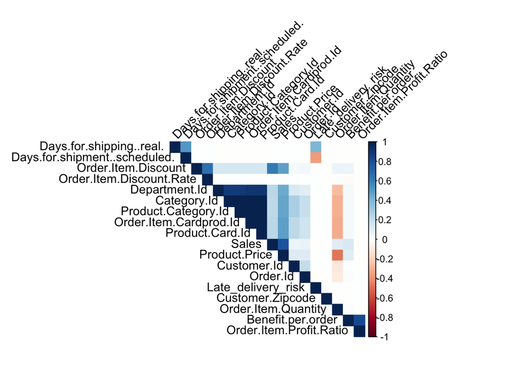

```r
# Correlation plot
numeric_data <- data[, sapply(data, is.numeric)]
cor_matrix <- cor(numeric_data)
corrplot(cor_matrix, method = "color", type = "upper", order = "hclust", tl.col = "black", tl.srt = 45)
```

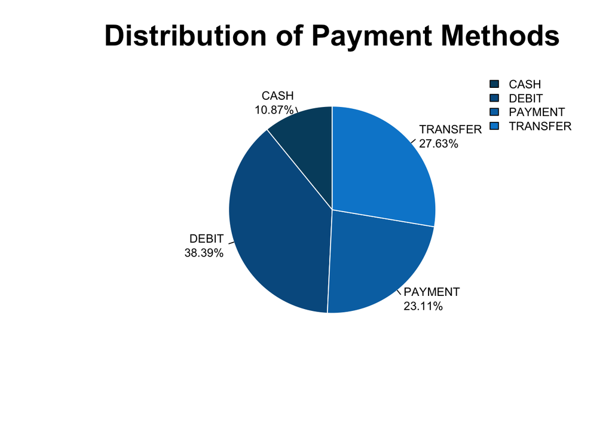

```r
library(ggplot2)
library(dplyr)
custom_colors <- c("#004c6d", "#005b8f", "#0072b2", "#0088d2", "#009fdd")


par(mar = c(5, 5, 4, 2))


category_counts <- table(data$Type)
percentage <- round((category_counts / sum(category_counts)) * 100, 2)

# Create labels with percentages
labels_with_percentage <- paste(names(category_counts), "\n", format(percentage, nsmall = 2), "%", sep = "")


pie(category_counts,
    labels = labels_with_percentage,

    col = custom_colors,
    cex = 0.8,
    init.angle = 90,
    border = "white"
)


legend("topright",
       legend = names(category_counts),
       fill = custom_colors,
       cex = 0.8,
       bty = "n"
)

title(main = "Distribution of Payment Methods", cex.main = 2)
```

From the figure, we can extrapolate that debit payments are the predominant method, accounting for over a third of all transactions. Electronic transfers also represent a significant portion, indicating a preference for cashless transactions. Cash payments, while still used, constitute the smallest share, suggesting a lesser role in the current payment landscape

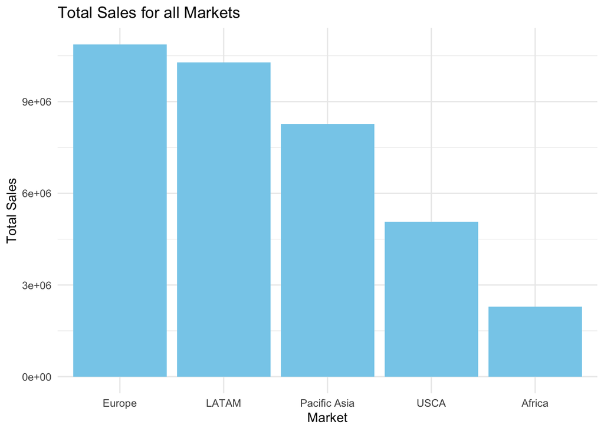

```r
# Grouping by Market
market <- data %>% group_by(Market)

# Plotting Total Sales for all Markets
plot_market <- market %>% summarise(total_sales = sum(`Sales`)) %>%
  arrange(desc(total_sales)) %>%
  ggplot(aes(x = reorder(Market, -total_sales), y = total_sales)) +
  geom_bar(stat = "identity", fill = "skyblue") +
  labs(title = "Total Sales for all Markets", x = "Market", y = "Total Sales") +
  theme_minimal()

# Display the plots
print(plot_market)
```

The bar chart indicates that Europe has the highest overall sales, while Africa shows the lowest total sales. Based on this observation, a new company looking to enter the market might consider prioritizing the European market over Africa.

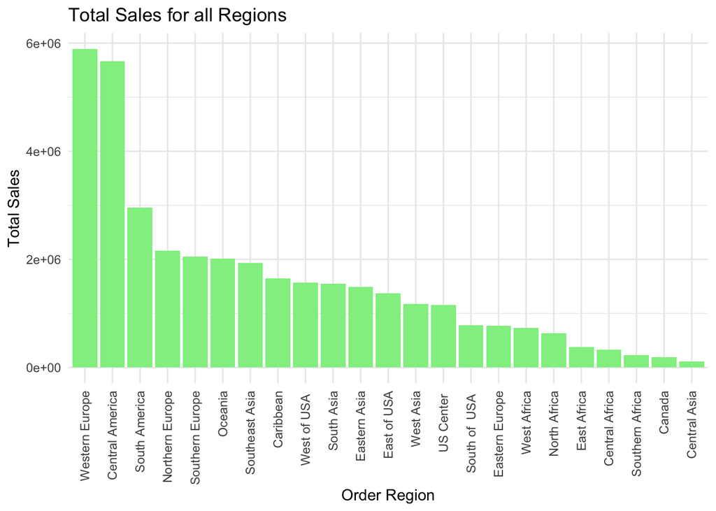

```r
# Grouping by Order Region
region <- data %>% group_by(`Order.Region`)
# Plotting Total Sales for all Regions
plot_region <- region %>% summarise(total_sales = sum(`Sales`)) %>%
  arrange(desc(total_sales)) %>%
  ggplot(aes(x = reorder(`Order.Region`, -total_sales), y = total_sales)) +
  geom_bar(stat = "identity", fill = "lightgreen") +
  labs(title = "Total Sales for all Regions", x = "Order Region", y = "Total Sales") +
  theme_minimal() +
  theme(axis.text.x = element_text(angle = 90, vjust = 0.5, hjust=1))
print(plot_region)
```

The bar chart illustrates that Western Europe and Central America top the list in terms of total sales by region, while Southern Africa, Canada, and the Central Asia region display the lowest sales. Consequently, emerging companies aiming to enter the market are advised to prioritize regions with the most significant sales figures.

```r
library(viridis)
```

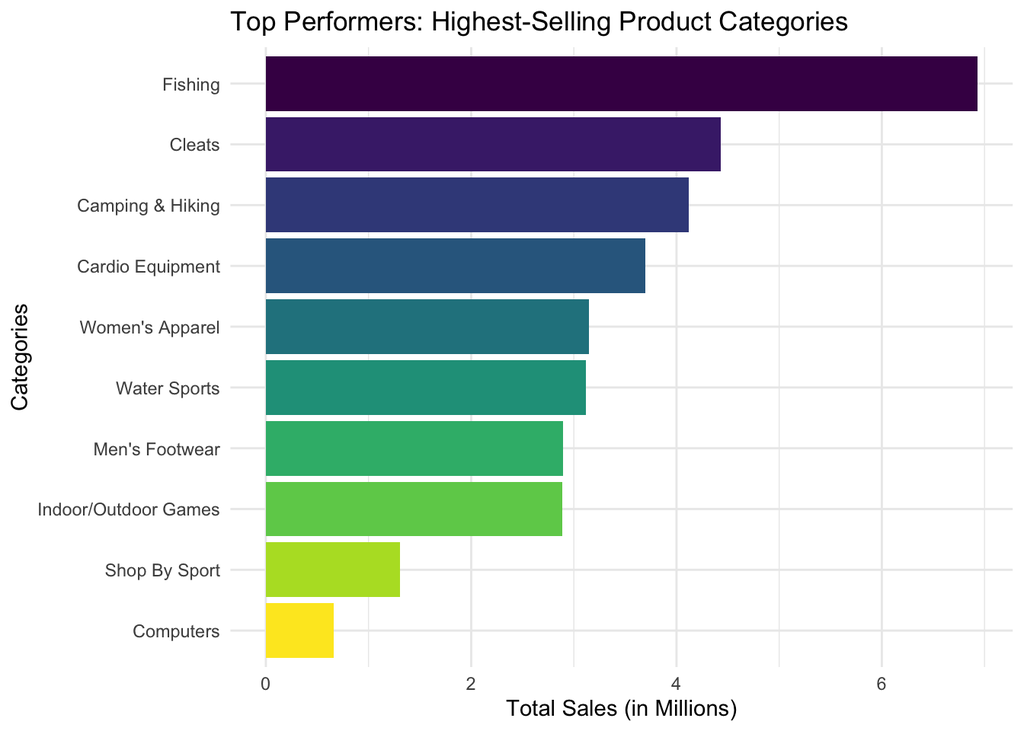

```r
total_sales_per_category <- data %>%
  group_by(Category.Name) %>%
  summarize(Total.Sales = sum(Sales)) %>%
  arrange(desc(Total.Sales))


top_10_categories <- head(total_sales_per_category, 10)


ggplot(top_10_categories, aes(x = reorder(Category.Name, Total.Sales), y = Total.Sales / 1e6)) +
  geom_bar(stat = "identity", fill = viridis(10)) +
  coord_flip() +
  labs(title = "Top Performers: Highest-Selling Product Categories",
       x = "Categories",
       y = "Total Sales (in Millions)") +
  theme_minimal() +
  theme(axis.text.y = element_text(angle = 0, hjust = 1)) +
  scale_y_continuous(breaks = c(0, 2, 4, 6), labels = c("0", "2", "4", "6"))
```

The chart reveals a strong market preference for outdoor and fitness-related products, with Fishing leading, while the Computers category shows minimal sales, indicating a potential area for improvement or re-evaluation.

```r
# Filter data for losses
loss <- data[data$`Benefit.per.order` < 0, ]

# Plotting top 10 products with most loss
plot_top_products <- loss %>%
  count(`Category.Name`) %>%
  arrange(desc(n)) %>%
  head(10) %>%
  ggplot(aes(x = reorder(`Category.Name`, -n), y = n)) +
  geom_bar(stat = "identity", fill = "salmon") +
  labs(title = "Products with Most Loss",
       x = "Category Name",
       y = "Number of Orders with Loss") +
  theme_minimal() +
  theme(axis.text.x = element_text(angle = 45, hjust = 1))

# Plotting top 10 regions with most loss
plot_top_regions <- loss %>%
  count(`Order.Region`) %>%
  arrange(desc(n)) %>%
  head(10) %>%
  ggplot(aes(x = reorder(`Order.Region`, -n), y = n)) +
  geom_bar(stat = "identity", fill = "skyblue") +
  labs(title = "Regions with Most Loss",
       x = "Order Region",
       y = "Number of Orders with Loss") +
  theme_minimal() +
  theme(axis.text.x = element_text(angle = 45, hjust = 1))

# Print total revenue lost with orders
cat("Total revenue lost with orders:", sum(loss$`Benefit.per.order`), "\n")
```

```
## Total revenue lost with orders: -3883547
```

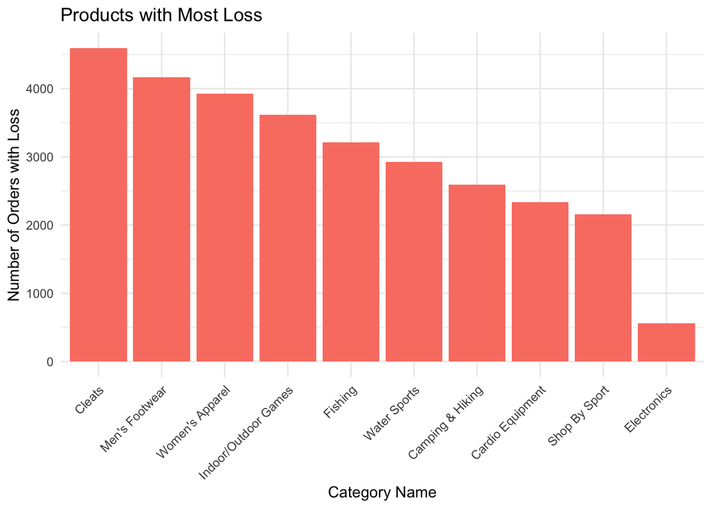

```r
# Display the plots
print(plot_top_products)
```

The bar chart shows that product categories related to clothing and footwear, specifically Cleats, Men’s Footwear, and Women’s Apparel, have the greatest number of orders that have resulted in losses, hinting at possible challenges in product satisfaction, return rates, or quality.

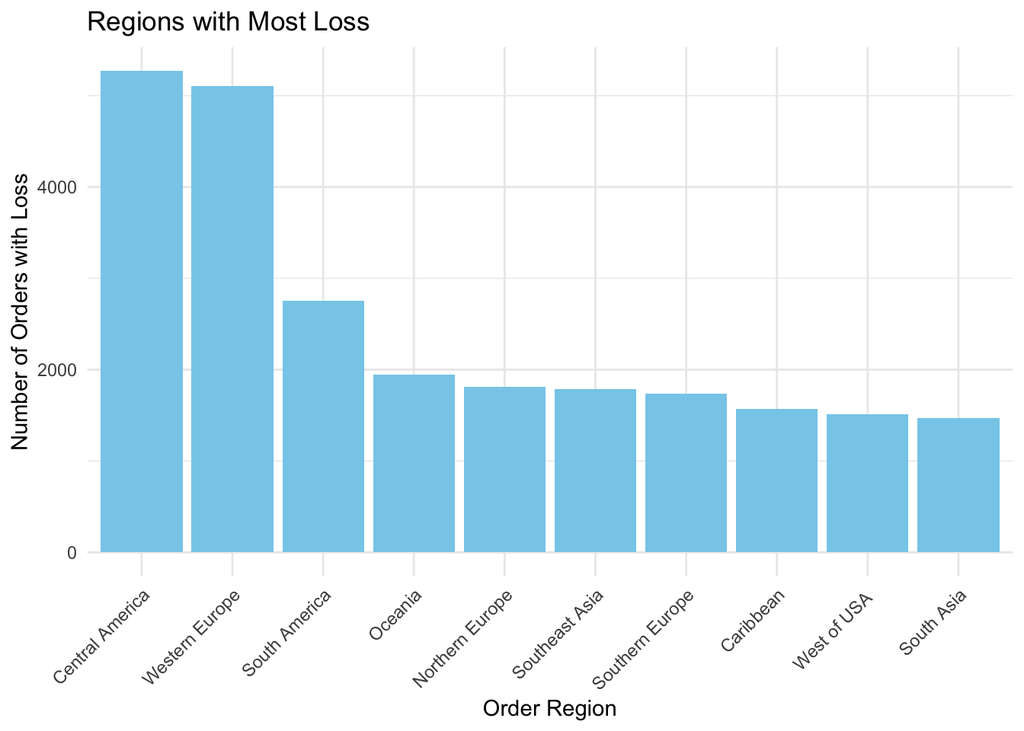

```r
print(plot_top_regions)
```

# Model Building

To determine the best model for predicting on-time product delivery, we first analyzed the problem’s binary classification nature and the data’s features, applying appropriate encoding techniques.

```r
library(forcats)
library(dplyr)
library(caret)
train_data <- data
train_data$fraud <- ifelse(train_data$`Order.Status` == 'SUSPECTED_FRAUD', 1, 0)
train_data$late_delivery <- ifelse(train_data$`Delivery.Status` == 'Late delivery', 1, 0)


train_data <- train_data %>%
  select(-Delivery.Status, -Late_delivery_risk, -Order.Status)

train_data <- train_data %>%
  mutate(
    `Customer.Country` = as.integer(fct_recode(as_factor(`Customer.Country`), .default = "NA")),
    Market = as.integer(fct_recode(as_factor(Market), .default = "NA")),
    Type = as.integer(fct_recode(as_factor(Type), .default = "NA")),
    `Product.Name` = as.integer(fct_recode(as_factor(`Product.Name`), .default = "NA")),
    `Customer.Segment` = as.integer(fct_recode(as_factor(`Customer.Segment`), .default = "NA")),
    `Customer.State` = as.integer(fct_recode(as_factor(`Customer.State`), .default = "NA")),
    `Order.Region` = as.integer(fct_recode(as_factor(`Order.Region`), .default = "NA")),
    `Order.City` = as.integer(fct_recode(as_factor(`Order.City`), .default = "NA")),
    `Category.Name` = as.integer(fct_recode(as_factor(`Category.Name`), .default = "NA")),
    `Customer.City` = as.integer(fct_recode(as_factor(`Customer.City`), .default = "NA")),
    `Department.Name` = as.integer(fct_recode(as_factor(`Department.Name`), .default = "NA")),
    `Order.State` = as.integer(fct_recode(as_factor(`Order.State`), .default = "NA")),
    `Shipping.Mode` = as.integer(fct_recode(as_factor(`Shipping.Mode`), .default = "NA")),
    `Order.Country` = as.integer(fct_recode(as_factor(`Order.Country`), .default = "NA")),
    `Customer.Full.Name` = as.integer(fct_recode(as_factor(`Customer.Full.Name`), .default = "NA"))
  )
set.seed(42)

xl <- train_data[, !(names(train_data) == "late_delivery")]
yl <- train_data$late_delivery
set_split_late_delivery <- createDataPartition(yl, p = 0.8, list = FALSE)
xl_train_late_delivery <- xl[set_split_late_delivery, ]
xl_test_late_delivery <- xl[-set_split_late_delivery, ]
yl_train <- yl[set_split_late_delivery]
yl_test <- yl[-set_split_late_delivery]

xl_train <- scale(xl_train_late_delivery)
xl_test <- scale(xl_test_late_delivery)
```

```r
classifier_model <- function( model_l, xl_train, xl_test, yl_train, yl_test) {


  model_l <- train(model_l, xl_train, yl_train)


  yl_pred <- predict(model_l, xl_test)



  accuracy_l <- sum(yl_pred == yl_test) / length(yl_test) * 100


  recall_l <- sum(yl_pred == 1 & yl_test == 1) / sum(yl_test == 1) * 100


  f1_l <- 2 * (recall_l * accuracy_l) / (recall_l + accuracy_l)


  cat("Accuracy of late delivery status is:", accuracy_l, "%\n")
  cat("Recall score of late delivery status is:", recall_l, "%\n")
  cat("F1 score of late delivery status is:", f1_l, "%\n")
}
```

#Model 1: Logistic Regression

```r
library(caret)


model_l <- glm(late_delivery ~ ., data = data.frame(late_delivery = yl_train, xl_train), family = binomial(link = "logit"))
classifier_model <- function( model_l,  xl_test, yl_test) {

  yl_pred <- predict(model_l, newdata = data.frame(xl_test), type = "response")


  accuracy_l <- sum((yl_pred >= 0.5) == yl_test) / length(yl_test) * 100


  recall_l <- sum((yl_pred >= 0.5) & yl_test == 1) / sum(yl_test == 1) * 100


  f1_l <- 2 * (recall_l * accuracy_l) / (recall_l + accuracy_l)


  cat("Accuracy of late delivery status is:", accuracy_l, "%\n")
  cat("Recall score of late delivery status is:", recall_l, "%\n")
  cat("F1 score of late delivery status is:", f1_l, "%\n")
}
classifier_model( model_l,xl_test, yl_test)
```

```
## Accuracy of late delivery status is: 98.88929 %
## Recall score of late delivery status is: 100 %
## F1 score of late delivery status is: 99.44154 %
```

- Among the three algorithms applied, this particular model shows exceptional performance in predicting late delivery status. It achieved a high accuracy of 98.89%, indicating its effectiveness in correctly identifying late deliveries.
- With a recall score of 100%, it successfully captured all actual late delivery instances, ensuring no late deliveries were misclassified as on-time.
- The F1 score of 99.44% further underscores its precision and reliability, making it a strong contender among the algorithms evaluated for this task.

#Model 2 Naive Bayes

```r
library(e1071)
model_l <- naiveBayes(yl_train ~ ., data = data.frame(yl_train, xl_train), laplace = 1)

classifier_model <- function( model_l, xl_test, yl_test) {

  yl_pred <- predict(model_l, newdata = data.frame(xl_test))


  accuracy_l <- sum(yl_pred == yl_test) / length(yl_test) * 100


  recall_l <- sum(yl_pred == 1 & yl_test == 1) / sum(yl_test == 1) * 100


  f1_l <- 2 * (recall_l * accuracy_l) / (recall_l + accuracy_l)


  cat("Accuracy of late delivery status is:", accuracy_l, "%\n")
  cat("Recall score of late delivery status is:", recall_l, "%\n")
  cat("F1 score of late delivery status is:", f1_l, "%\n")
}

classifier_model( model_l, xl_test, yl_test)
```

```
## Accuracy of late delivery status is: 42.90779 %
## Recall score of late delivery status is: 0 %
## F1 score of late delivery status is: 0 %
```

#Model 3 KNN

```r
if (!require(class)) {
  install.packages("class")
}
library(class)

model_l <- knn(xl_train, xl_test, yl_train, k = 1)

classifier_model <- function( model_l, xl_test, yl_test) {

  accuracy_l <- sum(model_l == yl_test) / length(yl_test) * 100

  recall_l <- sum(model_l == 1 & yl_test == 1) / sum(yl_test == 1) * 100


  f1_l <- 2 * (recall_l * accuracy_l) / (recall_l + accuracy_l)


  cat("Accuracy of late delivery status is:", accuracy_l, "%\n")
  cat("Recall score of late delivery status is:", recall_l, "%\n")
  cat("F1 score of late delivery status is:", f1_l, "%\n")
}
classifier_model( model_l, xl_test, yl_test)
```

```
## Accuracy of late delivery status is: 84.93477 %
## Recall score of late delivery status is: 86.03756 %
## F1 score of late delivery status is: 85.48261 %
```

- The results from applying the KNN algorithm to predict late delivery status show solid performance across metrics. It achieved an accuracy of 84.93%, indicating a high level of correctness in its predictions.
- The recall score of 86.04% demonstrates its effectiveness in identifying a majority of actual late deliveries. The F1 score, at 85.48%, indicates a good balance between precision and recall, suggesting that the model is reliable and consistent in its predictions for this specific task.

# Conclusion

Considering the performance metrics of the three algorithms – a Logistic Regression model, Naive Bayes, and KNN – in predicting late delivery status, the Logistic Regression model emerges as the best choice. It outperforms the others with an exceptionally high accuracy of 98.89% and a perfect recall score of 100%, indicating its superior capability in correctly identifying both late and on-time deliveries. Its F1 score of 99.44% further confirms its high precision and reliability.

In summary, the Logistic Regression model, with its outstanding accuracy, perfect recall, and excellent F1 score, is the most reliable and effective choice for predicting late delivery status in this scenario.